# Sars vs. COVID-19

Melodie Irvin, mki77

Virology has always excited me, and with the coronavirus looming around everywhere we go, I found it compelling to compare the current data regarding the deaths and confirmed cases of COVID-19 with it’s sister virus, SARS-CoV from 2003. Considering they are of the same genus and species of virus, I was expecting to find similar results regarding the number of deaths and rate of infection. As you will see, that is not at all the case. The Sars dataset was gathered from Kaggle while the COVID dataset was taken from ourworldindata.org. Both were combined in Excel prior to importing. The COVID dataset is up-to-date as of March 13, 2020.

```r
options(repos = "https://cran.rstudio.com")
library(dplyr)
library(formatR)
library(ggplot2)
library(readxl)
COVID_and_SARS <- read_excel("C:/Users/Melodie/Desktop/COVID_and_SARS.xlsx")
COVID_and_SARS <- COVID_and_SARS %>% slice(1:70)
COVID <- COVID_and_SARS %>% select(Date.Rank, Sum.of.COVID.Confirmed,
    Sum.of.COVID.Deaths)
SARS <- COVID_and_SARS %>% select(by = -c(Sum.of.COVID.Confirmed,
    Sum.of.COVID.Deaths)) %>% select(Day = Date.Rank, Sum.of.Sars.Deaths,
    Sum.of.Sars.Confirmed)
```

```r
library(tidyverse)
FULL <- full_join(COVID, SARS, by = c(Date.Rank = "Day"))
FULL_2 <- FULL %>% mutate(Week.Number = case_when(between(Date.Rank,
    1, 7) ~ "Week One", between(Date.Rank, 8, 14) ~ "Week Two",
    between(Date.Rank, 15, 21) ~ "Week Three", between(Date.Rank,
        22, 28) ~ "Week Four", between(Date.Rank, 29, 35) ~ "Week Five",
    between(Date.Rank, 36, 42) ~ "Week Six", between(Date.Rank,
        43, 49) ~ "Week Seven", between(Date.Rank, 50, 56) ~
        "Week Eight", between(Date.Rank, 57, 63) ~ "Week Nine",
    between(Date.Rank, 64, 70) ~ "Week Ten", between(Date.Rank,
        71, 77) ~ "Week Eleven", between(Date.Rank, 78, 84) ~
        "Week Twelve", between(Date.Rank, 85, 91) ~ "Week Thirteen",
    between(Date.Rank, 92, 96) ~ "Week Fourteen")) %>% select(Date.Rank,
    Sum.of.COVID.Confirmed, Sum.of.Sars.Confirmed, Sum.of.COVID.Deaths,
    Sum.of.Sars.Deaths, Week.Number)
FULL_New <- FULL_2 %>% arrange(Date.Rank) %>% mutate(COVID.New.Cases = Sum.of.COVID.Confirmed -
    lag(Sum.of.COVID.Confirmed)) %>% mutate(COVID.New.Deaths = Sum.of.COVID.Deaths -
    lag(Sum.of.COVID.Deaths)) %>% mutate(Sars.New.Cases = Sum.of.Sars.Confirmed -
    lag(Sum.of.Sars.Confirmed)) %>% mutate(Sars.New.Deaths = Sum.of.Sars.Deaths -
    lag(Sum.of.Sars.Deaths)) %>% select(Date.Rank, Sum.of.COVID.Confirmed,
    Sum.of.Sars.Confirmed, Sum.of.COVID.Deaths, Sum.of.Sars.Deaths,
    COVID.New.Cases, Sars.New.Cases, COVID.New.Deaths, Sars.New.Deaths,
    Week.Number)
```

Given that this data is tidy, the pivot_longer and pivot_wider fuctions will be used in another section. The object of using those functions, however, is to organize data so that each observation has it’s own row and each variable has it’s own column. I chose to do a full_join of the data because I imported a single dataset and wanted to ensure I kept all components, therefore, no results were lost. A few additional columns were made for gathering summary statistics as well as to create a categorical variable.

```r
FULL_New %>% filter(between(Date.Rank, 25, 50))
```

```
## # A tibble: 26 x 10
##    Date.Rank Sum.of.COVID.Co~ Sum.of.Sars.Con~ Sum.of.COVID.De~ Sum.of.Sars.Dea~
##        <dbl>            <dbl>            <dbl>            <dbl>            <dbl>
##  1        25            49053             3233             1383              144
##  2        26            50580             3298             1526              154
##  3        27            51857             3357             1669              159
##  4        28            71429             3448             1775              165
##  5        29            73332             3595             1873              182
##  6        30            75204             4090             2009              182
##  7        31            75748             4180             2129              217
##  8        32            76769             4561             2247              229
##  9        33            77794             4713             2359              251
## 10        34            78811             4921             2463              263
## # ... with 16 more rows, and 5 more variables: COVID.New.Cases <dbl>,
## #   Sars.New.Cases <dbl>, COVID.New.Deaths <dbl>, Sars.New.Deaths <dbl>,
## #   Week.Number <chr>
```

```r
FULL_New %>% select(Sum.of.COVID.Confirmed, Sum.of.Sars.Confirmed,
    everything()) %>% arrange(desc(Sum.of.COVID.Confirmed))
```

```
## # A tibble: 70 x 10
##    Sum.of.COVID.Co~ Sum.of.Sars.Con~ Date.Rank Sum.of.COVID.De~ Sum.of.Sars.Dea~
##               <dbl>            <dbl>     <dbl>            <dbl>            <dbl>
##  1           132758             7624        53             4955              610
##  2           125260             7569        52             4613              597
##  3           118319             7467        51             4292              586
##  4           113702             7445        50             4012              572
##  5           109577             7404        49             3809              551
##  6           105592             7280        48             3584              525
##  7           101927             7178        47             3486              513
##  8            98192             7074        46             3380              505
##  9            95324             6923        45             3280              494
## 10            93090             6800        44             3198              477
## # ... with 60 more rows, and 5 more variables: COVID.New.Cases <dbl>,
## #   Sars.New.Cases <dbl>, COVID.New.Deaths <dbl>, Sars.New.Deaths <dbl>,
## #   Week.Number <chr>
```

```r
FULL_New %>% slice(1:53) %>% group_by(Week.Number) %>% summarize(mean_COVNew = mean(COVID.New.Cases,
    na.rm = T), sd_COVNew = sd(COVID.New.Cases, na.rm = T))
```

```
## # A tibble: 8 x 3
##   Week.Number mean_COVNew sd_COVNew
##   <chr>             <dbl>     <dbl>
## 1 Week Eight        5795.     1672.
## 2 Week Five         1129.      563.
## 3 Week Four         4411.     6698.
## 4 Week One           419.      286.
## 5 Week Seven        2947       847.
## 6 Week Six          1374.      402.
## 7 Week Three        3309       423.
## 8 Week Two          2085.      484.
```

```r
FULL_New %>% slice(1:53) %>% summarize(median(Sum.of.COVID.Confirmed))
```

```
## # A tibble: 1 x 1
##   `median(Sum.of.COVID.Confirmed)`
##                              <dbl>
## 1                            51857
```

```r
FULL_New %>% summarize(median(Sum.of.Sars.Confirmed))
```

```
## # A tibble: 1 x 1
##   `median(Sum.of.Sars.Confirmed)`
##                             <dbl>
## 1                           5212.
```

```r
FULL_New %>% slice(1:53) %>% summarize(first(Sum.of.COVID.Deaths),
    last(Sum.of.COVID.Deaths), n_Week = n_distinct(Week.Number))
```

```
## # A tibble: 1 x 3
##   `first(Sum.of.COVID.Deaths)` `last(Sum.of.COVID.Deaths)` n_Week
##                          <dbl>                       <dbl>  <int>
## 1                            6                        4955      8
```

```r
FULL_New %>% summarize(first(Sum.of.Sars.Deaths), last(Sum.of.Sars.Deaths),
    n_Week = n_distinct(Week.Number))
```

```
## # A tibble: 1 x 3
##   `first(Sum.of.Sars.Deaths)` `last(Sum.of.Sars.Deaths)` n_Week
##                         <dbl>                      <dbl>  <int>
## 1                           4                        774     10
```

```r
FULL_New %>% group_by(Week.Number) %>% summarize(mean_SARNew = mean(Sars.New.Cases,
    na.rm = T), sd_SARNew = sd(Sars.New.Cases, na.rm = T))
```

```
## # A tibble: 10 x 3
##    Week.Number mean_SARNew sd_SARNew
##    <chr>             <dbl>     <dbl>
##  1 Week Eight        52.9      26.5
##  2 Week Five        237.      146.
##  3 Week Four         95.9      53.7
##  4 Week Nine         36.7      17.4
##  5 Week One          59.2      30.6
##  6 Week Seven       126.       19.9
##  7 Week Six         202        65.2
##  8 Week Ten           9.57      6.53
##  9 Week Three       129.      135.
## 10 Week Two         193.      288.
```

```r
FULL_New %>% na.omit %>% summarize(cor(Sars.New.Cases, COVID.New.Cases))
```

```
## # A tibble: 1 x 1
##   `cor(Sars.New.Cases, COVID.New.Cases)`
##                                    <dbl>
## 1                                 -0.124
```

```r
FULL_New %>% slice(1:53) %>% summarize(mean_CNC = mean(COVID.New.Cases,
    na.rm = T), sd(COVID.New.Cases, na.rm = T))
```

```
## # A tibble: 1 x 2
##   mean_CNC `sd(COVID.New.Cases, na.rm = T)`
##      <dbl>                            <dbl>
## 1    2548.                            2841.
```

```r
FULL_New %>% na.omit %>% summarize(var(COVID.New.Cases, COVID.New.Deaths))
```

```
## # A tibble: 1 x 1
##   `var(COVID.New.Cases, COVID.New.Deaths)`
##                                      <dbl>
## 1                                   81616.
```

```r
library(tidyverse)
library(kableExtra)
COOR <- FULL_New %>% na.omit %>% select_if(is.numeric)
kable(COOR) %>% kable_styling(fixed_thead = T)
```

| Date.Rank | Sum.of.COVID.Confirmed | Sum.of.Sars.Confirmed | Sum.of.COVID.Deaths | Sum.of.Sars.Deaths | COVID.New.Cases | Sars.New.Cases | COVID.New.Deaths | Sars.New.Deaths |
| --- | --- | --- | --- | --- | --- | --- | --- | --- |
| 2 | 314 | 231 | 6 | 4 | 32 | 64 | 0 | 0 |
| 3 | 581 | 278 | 17 | 9 | 267 | 47 | 11 | 5 |
| 4 | 846 | 317 | 25 | 10 | 265 | 39 | 8 | 1 |
| 5 | 1320 | 362 | 41 | 10 | 474 | 45 | 16 | 0 |
| 6 | 2014 | 403 | 56 | 11 | 694 | 41 | 15 | 1 |
| 7 | 2798 | 522 | 80 | 17 | 784 | 119 | 24 | 6 |
| 8 | 4593 | 554 | 106 | 17 | 1795 | 32 | 26 | 0 |
| 9 | 6065 | 1392 | 132 | 49 | 1472 | 838 | 26 | 32 |
| 10 | 7818 | 1478 | 170 | 53 | 1753 | 86 | 38 | 4 |
| 11 | 9826 | 1555 | 213 | 53 | 2008 | 77 | 43 | 0 |
| 12 | 11953 | 1619 | 259 | 54 | 2127 | 64 | 46 | 1 |
| 13 | 14557 | 1690 | 305 | 58 | 2604 | 71 | 46 | 4 |
| 14 | 17391 | 1871 | 362 | 62 | 2834 | 181 | 57 | 4 |
| 15 | 20630 | 2289 | 426 | 78 | 3239 | 418 | 64 | 16 |
| 16 | 24544 | 2338 | 492 | 79 | 3914 | 49 | 66 | 1 |
| 17 | 28276 | 2419 | 565 | 84 | 3732 | 81 | 73 | 5 |
| 18 | 31481 | 2479 | 638 | 89 | 3205 | 60 | 73 | 5 |
| 19 | 34886 | 2660 | 724 | 98 | 3405 | 181 | 86 | 9 |
| 20 | 37558 | 2725 | 813 | 103 | 2672 | 65 | 89 | 5 |
| 21 | 40554 | 2777 | 910 | 106 | 2996 | 52 | 97 | 3 |
| 22 | 43103 | 2843 | 1018 | 111 | 2549 | 66 | 108 | 5 |
| 23 | 45171 | 2952 | 1115 | 116 | 2068 | 109 | 97 | 5 |
| 24 | 46997 | 3022 | 1369 | 119 | 1826 | 70 | 254 | 3 |
| 25 | 49053 | 3233 | 1383 | 144 | 2056 | 211 | 14 | 25 |
| 26 | 50580 | 3298 | 1526 | 154 | 1527 | 65 | 143 | 10 |
| 27 | 51857 | 3357 | 1669 | 159 | 1277 | 59 | 143 | 5 |
| 28 | 71429 | 3448 | 1775 | 165 | 19572 | 91 | 106 | 6 |
| 29 | 73332 | 3595 | 1873 | 182 | 1903 | 147 | 98 | 17 |
| 30 | 75204 | 4090 | 2009 | 182 | 1872 | 495 | 136 | 0 |
| 31 | 75748 | 4180 | 2129 | 217 | 544 | 90 | 120 | 35 |
| 32 | 76769 | 4561 | 2247 | 229 | 1021 | 381 | 118 | 12 |
| 33 | 77794 | 4713 | 2359 | 251 | 1025 | 152 | 112 | 22 |
| 34 | 78811 | 4921 | 2463 | 263 | 1017 | 208 | 104 | 12 |
| 35 | 79331 | 5105 | 2618 | 274 | 520 | 184 | 155 | 11 |
| 36 | 80239 | 5318 | 2700 | 293 | 908 | 213 | 82 | 19 |
| 37 | 81109 | 5504 | 2762 | 321 | 870 | 186 | 62 | 28 |
| 38 | 82294 | 5688 | 2804 | 353 | 1185 | 184 | 42 | 32 |
| 39 | 83652 | 5870 | 2858 | 372 | 1358 | 182 | 54 | 19 |
| 40 | 85403 | 6211 | 2924 | 391 | 1751 | 341 | 66 | 19 |
| 41 | 87137 | 6349 | 2977 | 417 | 1734 | 138 | 53 | 26 |
| 42 | 88948 | 6519 | 3043 | 435 | 1811 | 170 | 66 | 18 |
| 43 | 90869 | 6671 | 3112 | 460 | 1921 | 152 | 69 | 25 |
| 44 | 93090 | 6800 | 3198 | 477 | 2221 | 129 | 86 | 17 |
| 45 | 95324 | 6923 | 3280 | 494 | 2234 | 123 | 82 | 17 |
| 46 | 98192 | 7074 | 3380 | 505 | 2868 | 151 | 100 | 11 |
| 47 | 101927 | 7178 | 3486 | 513 | 3735 | 104 | 106 | 8 |
| 48 | 105592 | 7280 | 3584 | 525 | 3665 | 102 | 98 | 12 |
| 49 | 109577 | 7404 | 3809 | 551 | 3985 | 124 | 225 | 26 |
| 50 | 113702 | 7445 | 4012 | 572 | 4125 | 41 | 203 | 21 |
| 51 | 118319 | 7467 | 4292 | 586 | 4617 | 22 | 280 | 14 |
| 52 | 125260 | 7569 | 4613 | 597 | 6941 | 102 | 321 | 11 |
| 53 | 132758 | 7624 | 4955 | 610 | 7498 | 55 | 342 | 13 |

```r
Tidycor <- cor(COOR) %>% as.data.frame %>% rownames_to_column %>%
    pivot_longer(-1, names_to = "name", values_to = "correlation")
head(Tidycor)
```

```
## # A tibble: 6 x 3
##   rowname   name                   correlation
##   <chr>     <chr>                        <dbl>
## 1 Date.Rank Date.Rank                    1
## 2 Date.Rank Sum.of.COVID.Confirmed       0.991
## 3 Date.Rank Sum.of.Sars.Confirmed        0.995
## 4 Date.Rank Sum.of.COVID.Deaths          0.986
## 5 Date.Rank Sum.of.Sars.Deaths           0.968
## 6 Date.Rank COVID.New.Cases              0.254
```

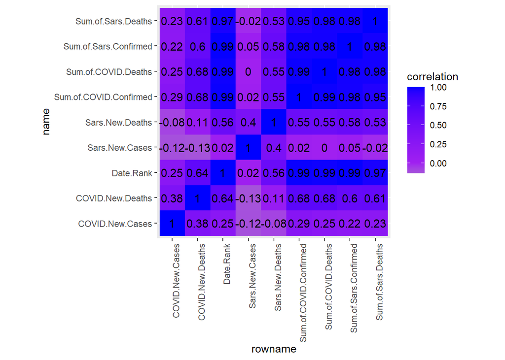

```r
Tidycor %>% ggplot(aes(rowname, name, fill = correlation)) +
    geom_tile() + scale_fill_gradient2(low = "green", mid = "purple",
    high = "blue") + geom_text(aes(label = round(correlation,
    2)), color = "black", size = 4) + theme(axis.text.x = element_text(angle = 90,
    hjust = 1)) + coord_fixed()
```